# EVome

Alex Cope

9/18/2020

I’m going to drop the Mixed sample for our data. Although Inna found that it was closer to Heavy EVs, it still could be considered its own group without any replicates. We have N=3 biological replicates for Heavy and Light EVs, which is the minimum we need to do a differential expression analysis.

The first thing I’m going to do is convert spectral counts to NSAF, which is a within sample normalization that accounts for protein length and total number of spectral counts taken in the sample.

Our data consists of multiple measurements taken on different instruments (Orbitrap, Eclipse) and on different days. This is begging for possible batch effects, which can reduce our signal of differential expression between the heavy and light fractions. Using the NSAF values, let’s cluster the different measurements to assess if we have a possible batch effect.

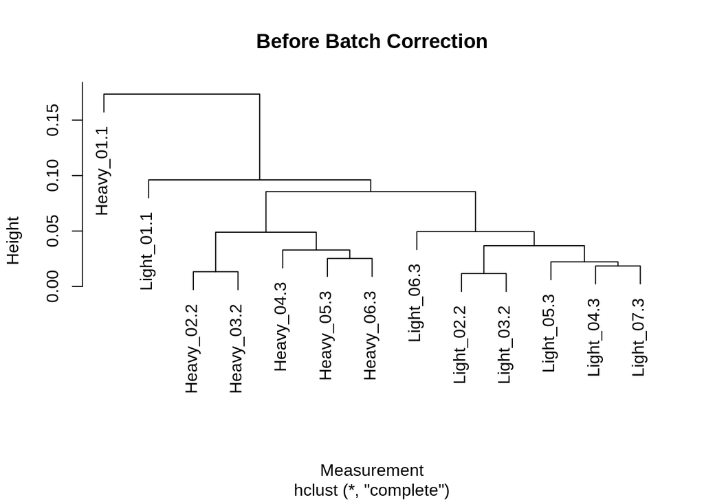

From the hierarchical clustering, it is Heavy_01 and Light_01 appear to be outliers, which is unsurprising given that they were measured on a different instrument. I’m going to apply the mean-centering correction method used in the Bioconductor package msmsEDA to reducte the batch effects. Note that the vignette for this tool states to treat missing values as 0. Question to investigate further: should we correct for batches before filtering (as done here) or after filtering of proteins with too many missing data points?

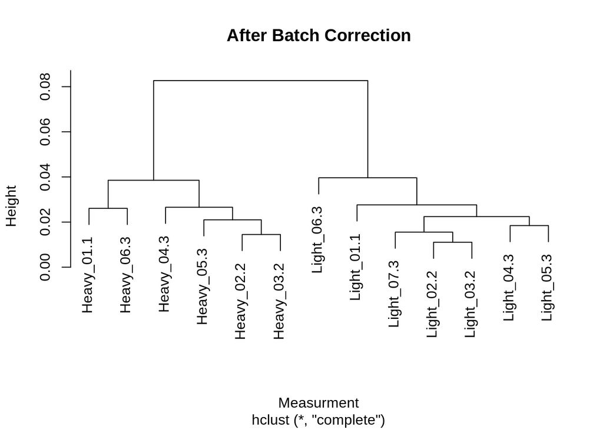

After applying the batch correction, Light_01 and Heavy_01 cluster with the other Light and Heavy EVomes, respectively.

Now that we’ve applied our batch corrections, let’s filter proteins. For our differential expression analysis, we ideally want proteins to be truly measured in 2 of the 3 biological replicates. We also don’t want proteins with too many missing values, so we will also remove any proteins missing in more than half of the measurements. After removal of these proteins, we will impute the remaining missing values.

After filtering, but before imputing, let’s normalize our samples to make them more comparable. We will apply the quantile normalization.

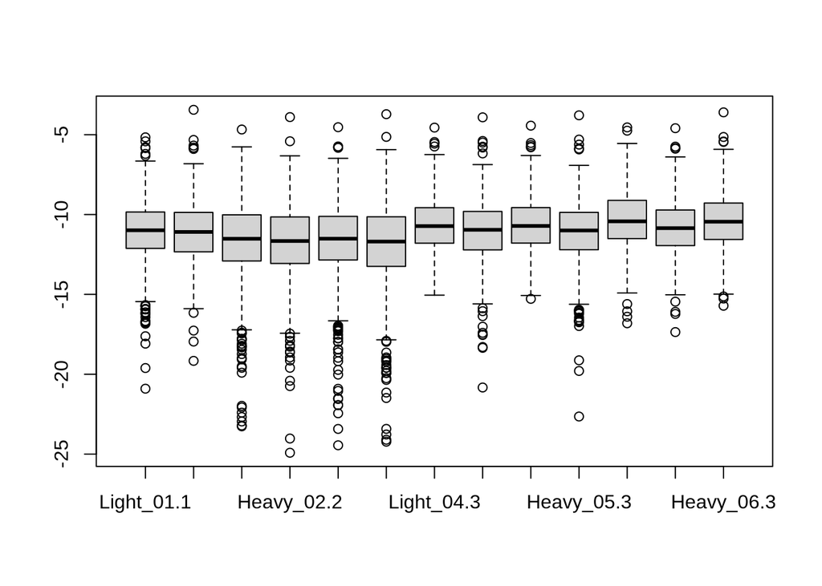

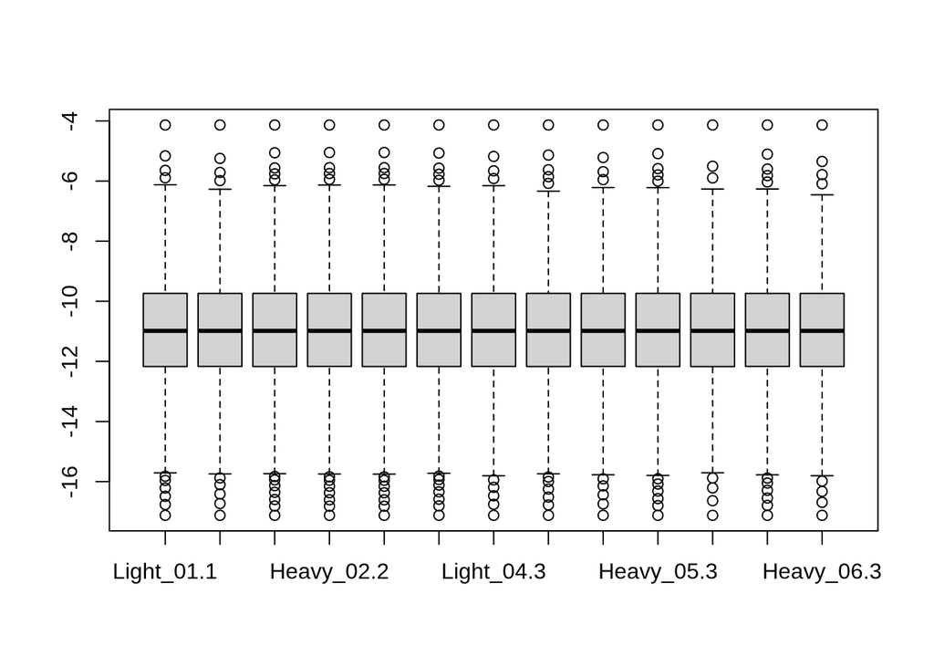

Next, we will impute missing values. In proteomics, missing values are often described as either missing at random or missing not at random. The latter refers to situation in which low abundant proteins are missing across samples. We can check if this is the case.

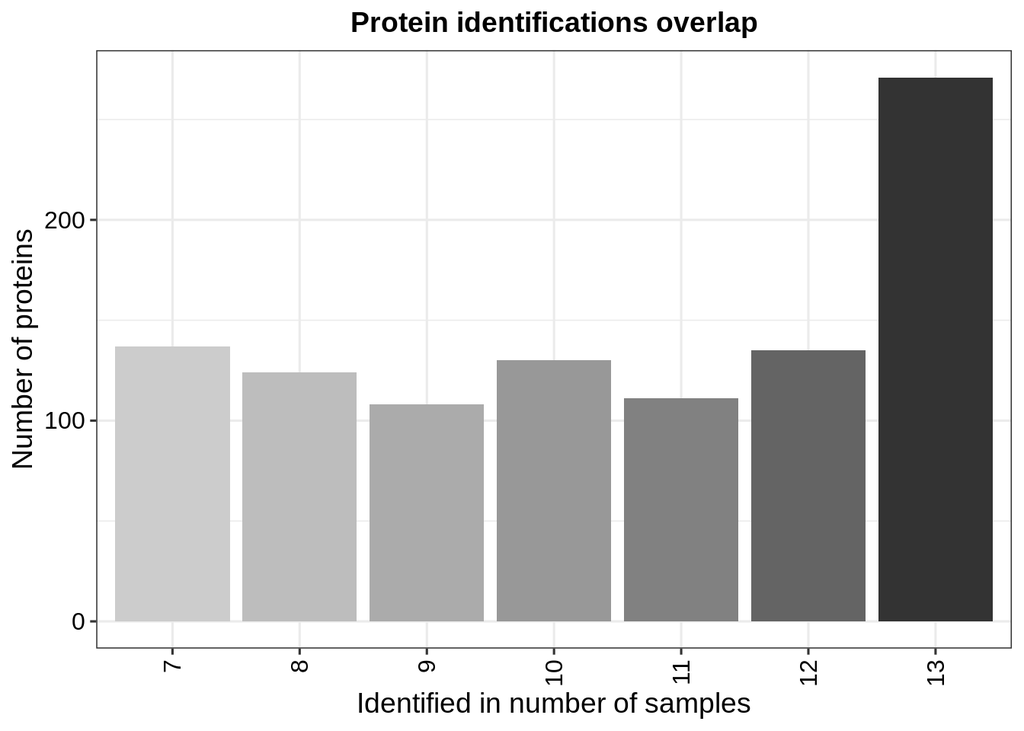

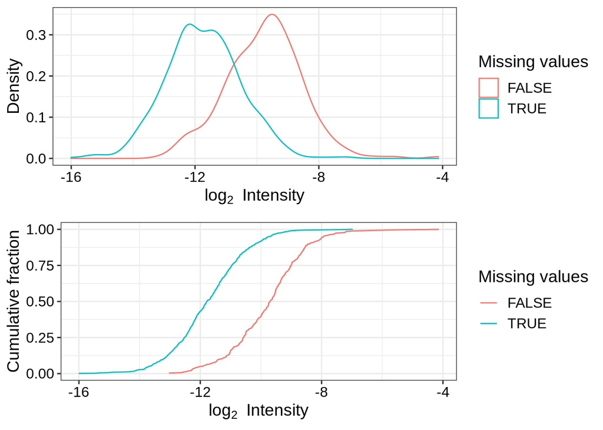

Based on the above plot, it appears that most of the missing values are from low abundant proteins. Here, we will use the QRILIC method of data imputation.

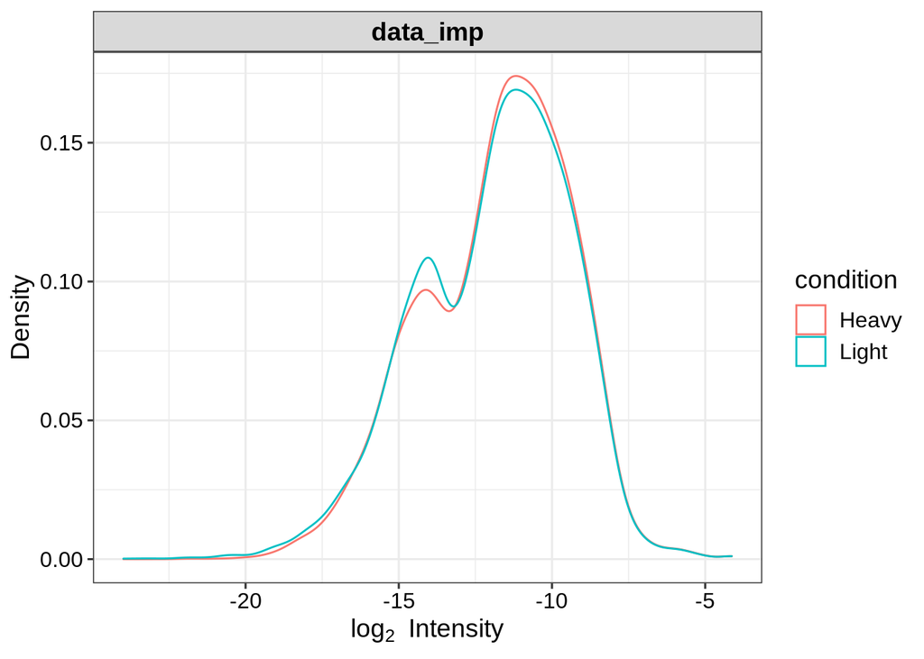

DEP log2 transforms the values and then imputes. We will use this matrix as input into limma for comparing protein abundances between the Heavy and Light fractions of EVs. We note that one check that the data fits limma’s assumptions is that variance is a monotonically decreasing function of average expression. We can check this assumption.

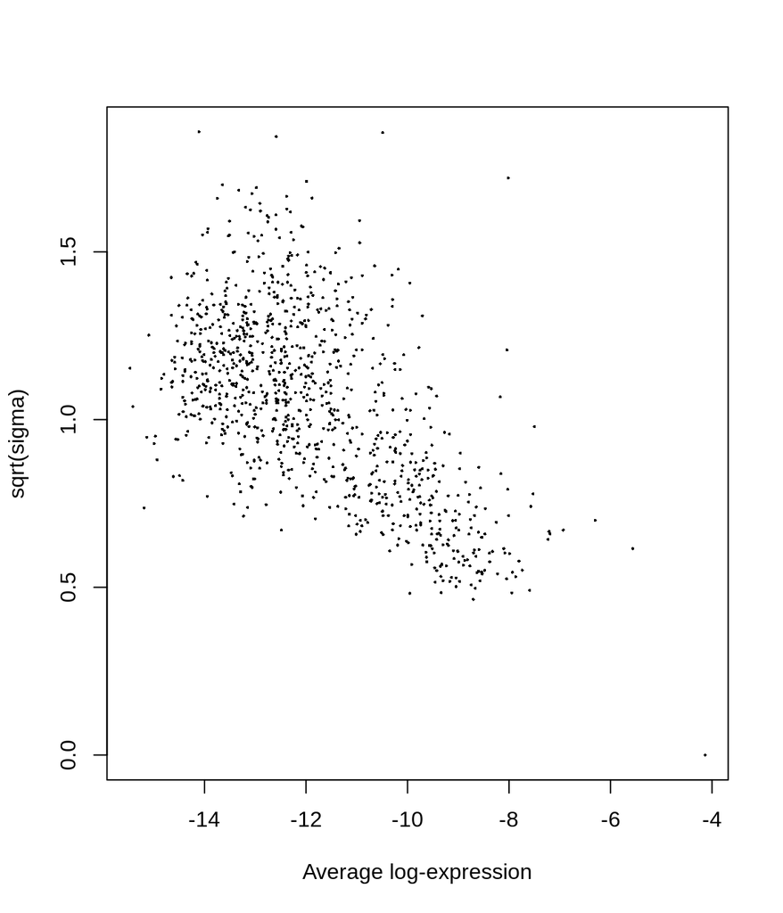

Based on this plot, seems like our data matches the assumptions of limma. Now let’s perform our differential expression analysis.

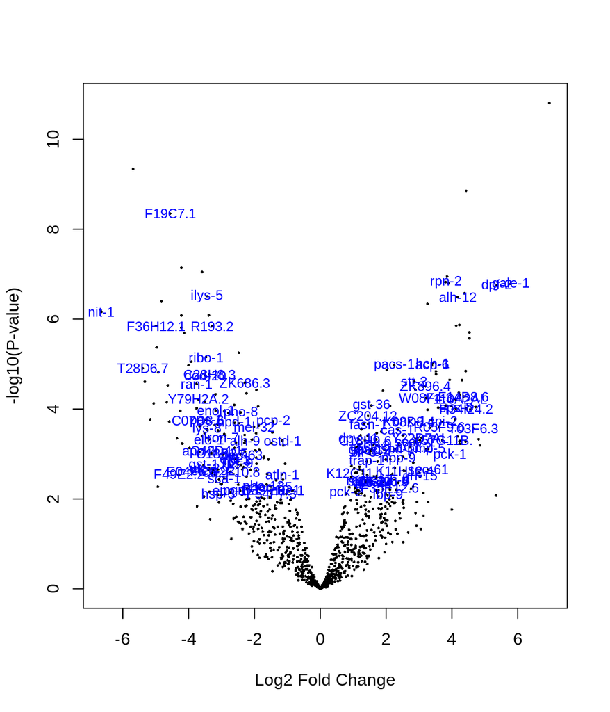